# Plotting Roman Roads and Time

by jaro

17 August 2021

### Roman roads network

This post concerns representation of ancient Roman roads *in time* with data from the article:

Fousek J, Kaše V, Mertel A, Výtvarová E, Chalupa A (2018) Spatial constraints on the diffusion of religious innovations: The case of early Christianity in the Roman Empire. PLoS ONE 13(12): e0208744. https://doi.org/10.1371/journal.pone.0208744

### Preliminaries

Load `"multigraph"` package and check its version.

```r
# load package and check version
library("multigraph")
packageVersion("multigraph")
```

```
[1] '0.95'
```

### Dataset

In the previous post , the data of the Roman Empire transport network consisted on three files that were `s007`, `s006`, and `s008` for edgelist with ancient cities travel costs, settlement labels with coordinates population estimates.

We work now with a dataset that is named `ponet` and which can be downloaded from GH

```r
source(file="https://raw.githubusercontent.com/sdam-au/R_code/master/data/ponet.r")
```

The last variable of the second data frame in the structure of this data records years with evidence of christianity. As with population estimates, there is missing data in this attribute.

```r
str(ponet)
```

```
List of 2
 $ net :'data.frame':   2394 obs. of  3 variables:
  ..$ from: int [1:2394] 50176 50176 50176 50177 50177 50178 50178 50179 50179 50179 ...
  ..$ to  : int [1:2394] 50250 50183 50031 50173 50109 50304 50346 50011 50516 50486 ...
  ..$ cost: num [1:2394] 1.162 1.545 3.695 0.931 0.958 ...
 $ attr:'data.frame':   672 obs. of  6 variables:
  ..$ id    : int [1:672] 50001 50002 50003 50004 50005 50006 50007 50008 50009 50010 ...
  ..$ label : Factor w/ 645 levels "Abodiacum","Acroceraunia Pr.",..: 1 4 5 6 3 7 8 9 10 11 ...
  ..$ XCOORD: Factor w/ 566 levels "0.0","22.987",..: 517 189 463 476 233 246 304 46 311 331 ...
  ..$ YCOORD: Factor w/ 569 levels "-0.089","-0.266018",..: 92 509 525 141 7 310 180 415 181 163 ...
  ..$ popest: num [1:672] NA NA NA NA NA NA NA 10000 NA 15000 ...
  ..$ christ: int [1:672] NA 200 NA NA 304 200 NA 304 NA NA ...
 - attr(*, "class")= chr "Dataset"
```

With the latest version of function `multigraph()` this dataset or other dataset is automatically plotted *as long as* has an object component named `net` that contains and array or, as in this case, an edgelist having one or more kinds of relations.

#### Graph representation

The following plot has a force directed layout whose coordinates are recorded in object `netcds` obtained from GH

```r
source(file="https://raw.githubusercontent.com/sdam-au/R_code/master/data/netcds.r")
```

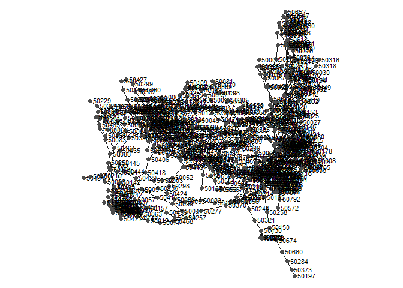

```r
# graph of network in 'ponet'
multigraph(ponet, directed=FALSE, coord=netcds)
```

However, many times is convenient to count with an object that records the adjacency matrix of the network, which in this case is valued rather than dichotomous.

```r
min(ponet$net[ponet$net>0])
```

```
[1] 0.07349514
```

Valued adjacency matrix

```r
# obtain matrix from send/receive/ties comma-separated-table
net <- multiplex::read.srt(ponet$net, header=TRUE, sep=",")
```

Dichotomous `net` from the minimum cost as the cut-off value.

```r
#  minimum cost is in 'ponet'
net0 <- multiplex::dichot(net, c=min(ponet$net[ponet$net>0]))
```

We plot the dichotomized network with settlement labels rather than their ids and using the layout coordinates of the previous graph. Since `ponet` is an aggregated dataset of `s007`, `s006`, and `s008`, there are entries in the network attributes with missing labels. We omit these to plot the network.

```r
# customize
scp <- list(directed=FALSE, pos=0, ecol=8, col=8, fsize=6)
```

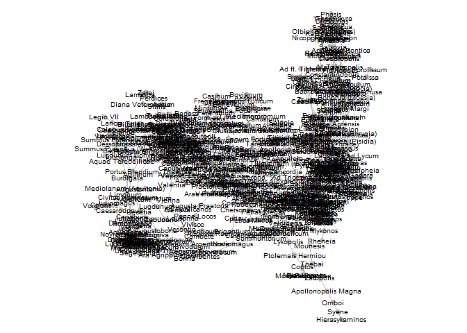

Graph with ancient Roman roads

```r
multigraph(net0, coord=netcds, scope=scp, lbs=na.omit(ponet$attr$label))
```

### Choosing settlements

The entries with population estimates are meant to be large cities.

```r
# network id labels
nlbs <- as.numeric(dimnames(net)[[1]])

# table with population estimates only
popltbl <- ponet$attr[-(na.action(na.omit(ponet$attr$popest))),]
```

```r
head(popltbl)
```

```
      id              label XCOORD YCOORD popest christ
8  50008             Aelana 29.664 34.974  10000    304
10 50010           Aesernia 41.594 14.231  15000     NA
11 50011            Aesuris 37.218 -7.445   8000    304
12 50012 Ara Agrippinensium 50.941   6.96  20000    200
14 50014      Ake-Ptolemais 32.922 35.077  10000    100
17 50017         Alexandria 31.201  29.91 500000    100
```

we choose the labels of these entries in table `popltbl`

```r
# 2nd column has labels in population estimates
lbs0 <- as.vector(popltbl[match(nlbs, popltbl$id),2])
```

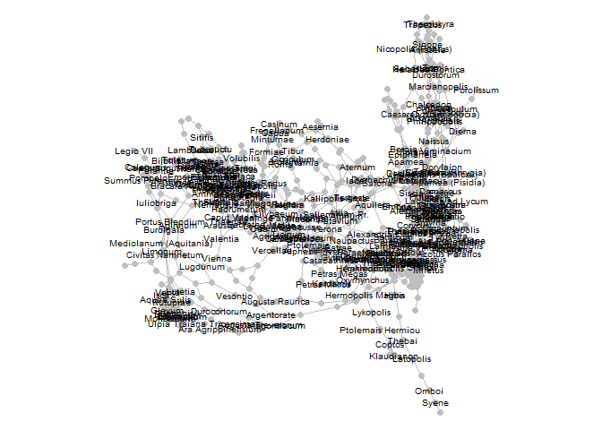

Roman roads and large cities

```r
multigraph(net0, coord=netcds, scope=scp, lbs=lbs0)
```

```r
# 5th column has population estimates
popl <- as.vector(popltbl[match(nlbs, popltbl$id),5])
```

```r
# last entries
tail(popl)
```

```
[1]   NA   NA 7000   NA 7000   NA
```

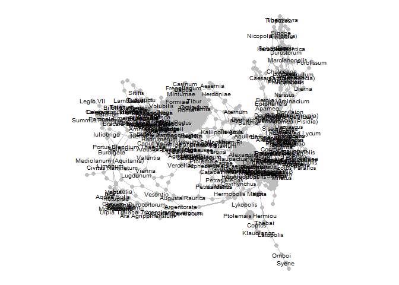

Roman roads with large cities as valued graph

```r
multigraph(net*100, coord=netcds, scope=scp, lbs=lbs0, cex=popl, valued=TRUE)
```

## Time dimension

For time, we create another table that records christianity.

```r
# Table with CHrist population only
xtbl <- ponet$attr[-(na.action(na.omit(ponet$attr$christ))),]
```

```r
head(xtbl)
```

```
      id              label XCOORD YCOORD popest christ
2  50002      Ad fl. Tigrim 37.325 42.196     NA    200
5  50005            Ad Aras   38.5   -0.5     NA    304
6  50006        Adramyttium 39.501 26.938     NA    200
8  50008             Aelana 29.664 34.974  10000    304
11 50011            Aesuris 37.218 -7.445   8000    304
12 50012 Ara Agrippinensium 50.941   6.96  20000    200
```

The three time points are the factor levels in component `christ` of `xtbl`.

```r
t1 <- xtbl[which(xtbl$christ==levels(factor(xtbl$christ))[1]),1:2]
head(t1)
```

```
      id              label
14 50014      Ake-Ptolemais
17 50017         Alexandria
18 50019   Alexandria Troas
23 50024          Antiochia
24 50025 Caesarea (Phrygia)
47 50050            Athenae
```

```r
t2 <- xtbl[which(xtbl$christ==levels(factor(xtbl$christ))[2]),1:2]
head(t2)
```

```
      id              label
2  50002      Ad fl. Tigrim
6  50006        Adramyttium
12 50012 Ara Agrippinensium
25 50026             Apamea
26 50027   Apamea (Pisidia)
67 50070           Berenice
```

```r
t3 <- xtbl[which(xtbl$christ==levels(factor(xtbl$christ))[3]),1:2]
head(t3)
```

```
      id       label
5  50005     Ad Aras
8  50008      Aelana
11 50011     Aesuris
15 50015 Alba Fucens
16 50016     Albulae
20 50021   Ammaedara
```

Again, we need to deal with missing information.

Once we count with the settlements in each point of time, we proceed with the construction of their adjacency matrices.

```r
# matrices
nett1 <- rel.sys(net0, type="toarray", sel=t1[,1])
nett2 <- rel.sys(net0, type="toarray", sel=t2[,1])
nett3 <- rel.sys(net0, type="toarray", sel=t3[,1])
```

### Adding missing nodes

However, not all `id` entries in `t1` to `t3` are in the above matrices

```r
t1[which(!(t1[,1]%in%dimnames(nett1)[[1]])),1]
```

```
[1] 50657
```

```r
t2[which(!(t2[,1]%in%dimnames(nett2)[[1]])),1]
```

```
[1] 50479 50481 50503 50615
```

```r
t3[which(!(t3[,1]%in%dimnames(nett3)[[1]])),1]
```

```
 [1] 50433 50477 50478 50484 50490 50616 50629 50659 50663 50668 50670 50675 50680 50685 50712
```

We can add the entries with argument `'add'` from function `transf()` available in the `"multiplex"` package.

```r
nett1a <- transf(nett1, type="toarray", add=t1[which(!(t1[,1]%in%dimnames(nett1)[[1]])),1])
nett2a <- transf(nett2, type="toarray", add=t2[which(!(t2[,1]%in%dimnames(nett2)[[1]])),1])
nett3a <- transf(nett3, type="toarray", add=t3[which(!(t3[,1]%in%dimnames(nett3)[[1]])),1])
```

## Plotting in time

```r
#define scope for time
scpt <- list(directed=FALSE, pos=0, ecol=8, fsize=6, col=8, cex=2.6, lwd=3, fsize=7)
```

### Time 1 (100 AD)

Settlements in time 1 with ids and labels are:

```r
title <- expression(bolditalic('t'[1])*'  (100 AD)')
```

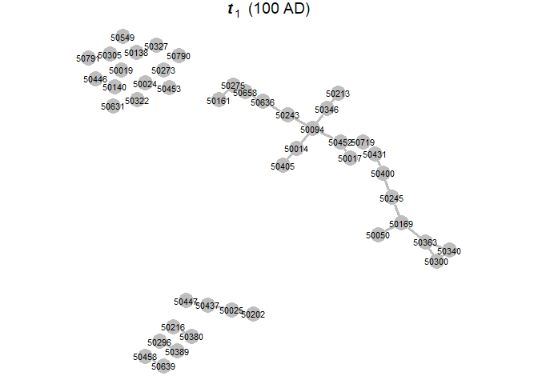

t_1 with city ids

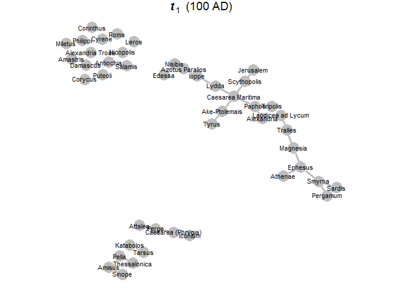

t_1 with city labels

```r
multigraph(nett1, layout="force", seed=12, rot=-9,
           scope=scpt, main=title)
```

```r
multigraph(nett1, "force", seed=12, rot=-9,
           scope=scpt, main=title, lbs=na.omit(t1[,2]))
```

### Time 2 (200 (AD)

Settlements in time 2 with ids and labels are:

```r
title <- expression(bolditalic('t'[2])*'  (200 AD)')
```

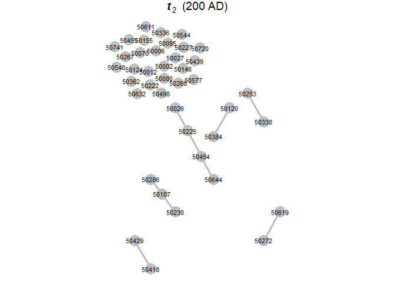

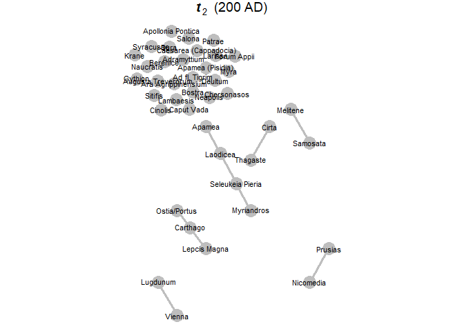

```r
multigraph(nett2, layout="force", seed=10,
           scope=scpt, main=title)
```

```r
multigraph(nett2, layout="force", seed=10,
           scope=scpt, main=title, lbs=na.omit(t2[,2]))
```

### Time 3 (304 AD)

Settlements in time 3 with ids and labels are:

```r
scpt <- list(directed=FALSE, pos=0, ecol=8, fsize=6, col=8, cex=1.2, lwd=3, fsize=5)
title <- expression(bolditalic('t'[3])*'  (304 AD)')
```

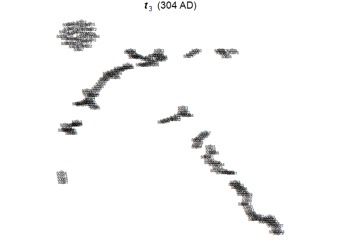

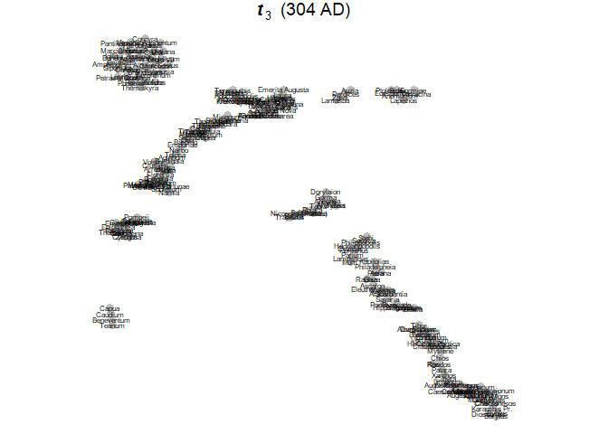

```r
multigraph(nett3, layout="force", seed=96,
           scope=scpt, main=title)
```

```r
multigraph(nett3, layout="force", seed=96,
           scope=scpt, main=title, lbs=na.omit(t3[,2]))
```

### Transport network

```r
# labels
lbs1 <- as.vector(t1[match(nlbs, t1$id),2])
lbs2 <- as.vector(t2[match(nlbs, t2$id),2])
lbs3 <- as.vector(t3[match(nlbs, t3$id),2])
```

Clustering of nodes at the three points of time.

```r
# clustering
ct1 <- ct2 <- ct3 <- vector(length=dim(net0)[1])
#
ct1[which(dimnames(net0)[[1]]%in%t1[,1])] <- 1
ct2[which(dimnames(net0)[[1]]%in%t2[,1])] <- 2
ct3[which(dimnames(net0)[[1]]%in%t3[,1])] <- 3
```

```r
# another scope for time
scpt0 <- list(directed=FALSE, pos=0, ecol=8, fsize=7)
```

```r
title <- expression(bolditalic('t'[1])*'  (100 AD)')
```

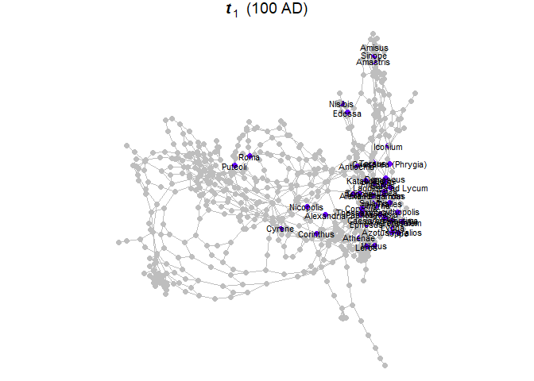

Roman roads with christianity 100 AD

```r
multigraph(net0, coord=netcds, scope=scpt0, clu=ct1, col=c("gray","#6600FF"), lbs=lbs1, main=title)
```

```r
title <- expression(bolditalic('t'[2])*'  (200 AD)')
```

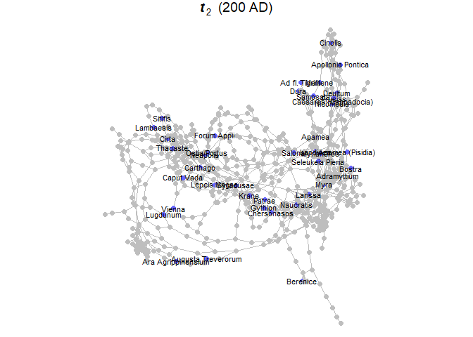

Roman roads with christianity 200 AD

```r
multigraph(net0, coord=netcds, scope=scpt0, clu=ct2, col=c("gray","#6666FF"), lbs=lbs2, main=title)
```

```r
title <- expression(bolditalic('t'[3])*'  (304 AD)')
```

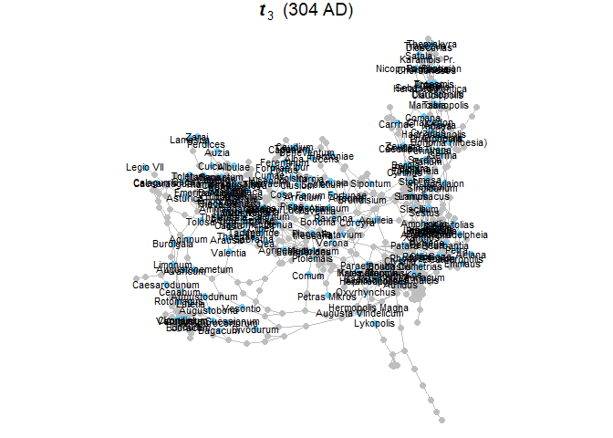

Roman roads with christianity 304 AD

```r
multigraph(net0, coord=netcds, scope=scpt0, clu=ct3, col=c("gray","#66CCFF"), lbs=lbs3, main=title)
```

## Cumulated

```r
ct123 <- vector(length=dim(net0)[1])

ct123[which(dimnames(net0)[[1]]%in%t1[,1])] <- 1
ct123[which(dimnames(net0)[[1]]%in%t2[,1])] <- 2
ct123[which(dimnames(net0)[[1]]%in%t3[,1])] <- 3
```

We create the labels of settlements in the three points of time.

```r
lbs123 <- as.vector(mapply(function(...) {tmp <- c(...); tmp[!is.na(tmp)][1]}, lbs1,lbs2,lbs3))
```

And plot with customized graph.

```r
scptp <- list(pos=0, ecol=8, alpha=c(.8,.8), clu=ct123, col=c("gray","#6600FF","#6666FF","#66CCFF"), showLbs=F)
title <- expression(bolditalic('t'[1-3])*'  (100, 200, 304 AD)')
```

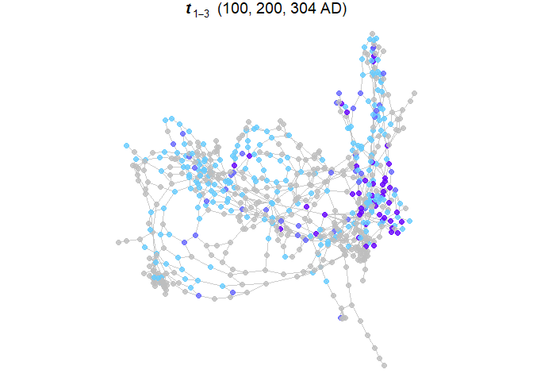

Roman roads with christianity 100-200-304 AD

```r
multigraph(net0, directed=FALSE, coord=netcds, scope=scptp, lbs=lbs123, main=title)
```

### See also

- [Plotting Roman Empire transport network](https://sdam-au.github.io/sdam/articles/TransportNetwork.html)
- [Plotting ancient Roman provinces and regions](https://sdam-au.github.io/sdam/articles/RomanProvs.html)
- [Re-encoding Greek characters from ‘EDH’ dataset](https://sdam-au.github.io/sdam/articles/Encoding.html)
- [`"sdam"` manual](https://github.com/mplex/cedhar/blob/master/typesetting/reports/sdam.pdf)
- [Social Dynamics and complexity in the Ancient Mediterranean Project](https://sdam-au.github.io/sdam-au/)